# Analyse Motif Gains at Disordered Cytosolic Tails of Transmembrane Proteins using ClinVar variants

Thu Nov 8 13:47:03 2018

```r
library(slimR)
library(rtracklayer)
library(Biostrings)
library(data.table)
library(ggplot2)
library(stringi)
library(parallel)
library(biomaRt)
library(ggrepel)
library(pbapply)
library(GenomicRanges)
```

# 1 Introduction

This vignette explains how to screen the proteome for gains of short linear motifs via disease-causing or polymorphic single amino-acid variations.

- Variation data: Clinvar Database
- Short linear motif annotations: ELM database
- Disorder predictions using IUPred tool.
- Protein sequence and feature annotations from Uniprot database.

We make use of the slimR package along with other R/Bioconductor packages to show how to screen the transmembrane proteins for gains/losses of short linear motifs. Moreover, this code shows the results that were obtained and published in the paper: https://www.sciencedirect.com/science/article/pii/S0092867418310353

# 2 Prepare datasets

## 2.1 Downloading human protein sequences from Uniprot

How to download the latest protein sequence annotations from Uniprot:

```
# download uniprot fasta and import
fastaFile <- slimR::getUniprotData(outDir = datadir, format = 'fasta', update = TRUE)
fasta <- Biostrings::readAAStringSet(fastaFile)
#process fasta headers to keep only uniprot accessions
names(fasta) <- sub("^sp\\|(.+?)\\|.*", "\\1", names(fasta))
```

We will import already downloaded fasta sequences:

```r
fasta <- Biostrings::readAAStringSet(file.path(datadir, 'uniprot.9606.Nov_8_2018.fasta.gz'))
#process fasta headers to keep only uniprot accessions
names(fasta) <- sub("^sp\\|(.+?)\\|.*", "\\1", names(fasta))
```

## 2.2 Downloading human protein sequence features from Uniprot in GFF format

In order to download the latest protein sequence features:

```
gffFile <- slimR::getUniprotData(outDir = datadir, format = 'gff', update = TRUE)
gff <- rtracklayer::import.gff(gffFile)
```

We will import already processed GFF data:

```r
gff <- readRDS(file.path(datadir, 'uniprot.9606.Nov_8_2018.gff.RDS'))
```

## 2.3 Download Short Linear Motif regular expressions

In order to downlaod the latest Short Linear Motif (SLiM) expressions from the ELM database (http://elm.eu.org):

```
slim_regex <- slimR::getElmClasses()
```

It is also possible to add more custom SLiM definitions like this:

```
slim_regex <- c(slim_regex, list('LIG_diLeu_1' = '.LL.'))
```

Instead, we’ll use already downloaded SLiM expressions back in April, 2017, which also contains a diLeucine motif.

```r
slim_regex <- readRDS(file.path(datadir, 'elm_classes.RDS'))
```

## 2.4 Running IUPred

slimR package contains a wrapper function that accepts a fasta format file and runs the IUPred tool to get per-residue disorder propensity scores. See ?slimR::runIUpred for more information on how to download and install IUPred tool.

```
iupred <- slimR::runIUPred(iupredPath = '/home/buyar/tools/iupred',
                           fastaFile = '../data/uniprot.9606.Nov_8_2018.fasta.gz',
                           nodeN = 10)
#process to keep only uniprot accessions
names(iupred) <- sub("^sp\\|(.+?)\\|.*", "\\1", names(iupred))
```

Again, we import an already pre-processed iupred score object that was run on the previously imported fasta file.

```r
iupred <- readRDS(file.path(datadir, 'uniprot.9606.Nov_8_2018.iupred.RDS'))
```

## 2.5 Downloading single amino acid variants

# 3 Import Clinvar variants

Here is the description of how the clinvar variants were processed in the methods section of Meyer et al.

The version of the Clinvar variant data that was used in the paper can be downloaded from here:

```r
file.path(datadir, 'variant_summary.txt.gz')
```

```
## [1] "./data/variant_summary.txt.gz"
```

The latest version of Clinvar variants can be downloaded from here: ftp://ftp.ncbi.nlm.nih.gov/pub/clinvar/tab_delimited/variant_summary.txt.gz

Below is shown, how the clinvar variants are processed: Single nucleotide variants for the human genome assembly GRCh38 are selected. Then, Ensemble variant_effect_predictor version 82 is run to translate the single nucleotide variants to find the single amino acid variants in uniprot sequences.

```r
clinvarData <- data.table::fread(file.path(datadir, 'variant_summary.txt.gz'))

clinvarData <- clinvarData[Type == 'single nucleotide variant' &
                             Assembly == 'GRCh38']

#subset the clinvar data by columns, write to a file and pass to variant_effect_predictor.pl (VEP)
clinvarData$Allele <- paste(clinvarData$ReferenceAllele,
                            clinvarData$AlternateAllele, sep = '/')
#clinvar uses the positive strand as reference nucleotide
clinvarData$Strand <- '+'
clinvarData$Name <- gsub(' ', '_', clinvarData$Name)
# identifier created to uniquely refer to every row in the data table. this
# is used as input to VEP and later used to merge VEP results with some of
# the clinvarData fields (e.g. dbSNP id etc)
clinvarData$Identifier <- paste(clinvarData$Chromosome, clinvarData$Start,
                                clinvarData$Stop, clinvarData$Name,
                                sep = ':')
# save the table to file to be passed to variant_effect_predictor tool.
write.table(x = clinvarData[,c('Chromosome', 'Start', 'Stop',
                               'Allele', 'Strand', 'Identifier')],
            file = 'clinvarData.processed.tsv', quote = F,
            sep = '\t', row.names = F, col.names = F)
```

variant_effect_predictor version 82 was run for the selected single nucleotide variants

```r
command <- paste("variant_effect_predictor.pl
                  -i clinvarData.processed.tsv
                  -o clinvarData.processed.VEPoutput.tsv
                   --cache --uniprot --force_overwrite --fork 8")
system(command)
```

The resulting file can be found here:

```r
file.path(datadir, 'clinvarData.processed.VEPoutput.tsv.gz')
```

```
## [1] "./data/clinvarData.processed.VEPoutput.tsv.gz"
```

VEP results are further processed to find missense variants that are translated into SwissProt/Uniprot sequences. Here, we are using already processed VEP output:

```r
vepRaw <- data.table::fread(file.path(datadir, 'clinvarData.processed.VEPoutput.tsv.gz'), header = T)
cat("Read",nrow(vepRaw),"mappings of",nrow(unique(vepRaw[,1])),"unique variants \n")

#filter for missense variants with swissprot ids
vep <- vepRaw[grepl(pattern = 'SWISSPROT', x = vepRaw$Extra)]

cat("Removing mappings that don't have a SWISSPROT ID...\n",
    "\tkeeping",nrow(vep),"mappings of",nrow(unique(vep[,1])),
    "unique variants \n")

vep <- vep[Consequence == 'missense_variant']

cat("Removing variants that don't lead to a single amino-acid substitution...\n",
    "\tkeeping",nrow(vep),"mappings of",nrow(unique(vep[,1])),
    "unique variants\n")

#extract uniprot accession numbers and create a new column
cl <- parallel::makeCluster(10)
parallel::clusterExport(cl, varlist = c('vep'), envir = environment())
vep$uniprotAccession <- gsub(pattern = '(SWISSPROT=|;$)', replacement = '', do.call(c, parLapply(cl, vep$Extra, function(x) {
  unlist(stringi::stri_extract_all(str = x, regex = 'SWISSPROT=.*?;'))
})))
parallel::stopCluster(cl)
colnames(vep)[1] <- 'Identifier'

#remove rows where multiple amino acids are reported for missense variants
vep <- vep[grep('^.\\/.$', vep$Amino_acids),]
cat("Removed variants where multiple amino acids are reported for missense variants...\n",
    "\tkeeping",nrow(vep),"mappings of",nrow(unique(vep[,1])),
    "unique variants \n")

#add extra columns about the mutation positions and amino acids
vep$pos <- as.numeric(vep$Protein_position)
vep$wtAA <- gsub(pattern = '\\/.$', '', vep$Amino_acids)
vep$mutAA <- gsub(pattern = '^.\\/', '', vep$Amino_acids)
```

Thus, at this point, we should have 256,802 mappings of 109,922 unique variants. Notice that a single nucleotide variant can be mapped to one or more single amino acid variants (due to overlapping annotations of genes).

Now, we merge VEP data with the original clinvar data (notice that VEP results will only contain missense-variants, so the clinvar data will be down-sized to only those that have a calculated consequence of ‘missense variant’ according to VEP)

```r
clinvarVEPdata <- merge(clinvarData, vep, by = 'Identifier')
```

# 4 More sanity checks

The clinvar table contains a `Name` field which contains information about the variant such as the gene name and the translated amino-acid change (e.g. “NM_014630.2(ZNF592):c.3136G>A_(p.Gly1046Arg)”). Ideally, if this `Name` field contained the Uniprot Accession number instead of the gene name, then we wouldn’t have to go through all the previous pre-processing steps. However, we would like to stick to the original Clinvar annotation and pick the translated amino acid variants via VEP that actually match the records in the `Name` field.

```r
# apply a filter to match clinvar variants (using the identifier/name field) with the translated variants on uniprot sequences
clinvarMutations <- slimR::parseMutation(stringi::stri_extract(str = clinvarVEPdata$Identifier, regex = 'p\\....\\d+...'))

matchedVars <- paste(clinvarMutations$wtAA, clinvarMutations$pos, clinvarMutations$mutAA, sep = ':') == paste(clinvarVEPdata$wtAA, clinvarVEPdata$pos, clinvarVEPdata$mutAA, sep = ':')
clinvarVEPdata <- clinvarVEPdata[matchedVars]

# apply another filter to match the gene names for clinvar variants and
# gene names of the translated variants on uniprot sequences
# get a table of reviewed uniprot ids and their gene names
getUniProt2HGNC<- function (uniprotAccessions) {
  ensembl <- biomaRt::useMart('ensembl', dataset="hsapiens_gene_ensembl")
  annotation <- biomaRt::getBM(attributes=c("uniprotswissprot", "hgnc_symbol"),
                    filters="uniprotswissprot",
                    values=uniprotAccessions,
                    mart=ensembl)
  return(annotation)
}

uni2hgnc <- getUniProt2HGNC(unique(clinvarVEPdata$uniprotAccession))
clinvarVEPdata$mappedGeneSymbol <- uni2hgnc[match(clinvarVEPdata$uniprotAccession, uni2hgnc$uniprotswissprot),]$hgnc_symbol
clinvarVEPdata <- clinvarVEPdata[clinvarVEPdata$GeneSymbol == clinvarVEPdata$mappedGeneSymbol]
```

We also need to make sure that the fasta records of the Uniprot sequences contain exactly the same wild-type residue at the given position.

First, we make sure of this by checking if the translated amino acid variant matches the residue in the fasta records. The will add a new column called ‘validity’ with TRUE/FALSE values. If TRUE, the translated wild-type residue at the given position exactly matches the residue at the corresponding position of the current protein sequence.

```r
clinvarVEPdata <- slimR::validateVariants(df = clinvarVEPdata, fasta = fasta, nodeN = 10)

clinvarVEPdata <- clinvarVEPdata[validity == TRUE]
```

Now, we’d like to add two more columns to the variants table, which will be used to filter variants by 1. disorder propensity scores, 2. overlap with annotated protein domains, which will be needed when looking for motif gain/losses in the sequences due to amino-acid variants.

```r
#add disorder score field to each variant
clinvarVEPdata$iupredScore <- pbapply::pbapply(as.data.table(clinvarVEPdata), 1, function(x) {
  uni <- x[['uniprotAccession']]
  pos <- as.numeric(x[['pos']])
  score <- iupred[[uni]][pos]
  return(score)
})

#find out if variants overlap any known domains
clinvarVEPdata.gr <- makeGRangesFromDataFrame(clinvarVEPdata, ignore.strand = TRUE,
                                              start.field = 'pos',
                                              end.field = 'pos',
                                              seqnames.field = 'uniprotAccession')
clinvarVEPdata$overlapsDomain <- FALSE
clinvarVEPdata[unique(queryHits(findOverlaps(clinvarVEPdata.gr, gff[gff$type == 'Domain',]))),]$overlapsDomain <- TRUE
```

The resulting table can be found here as an RDS file.

```r
file.path(datadir, 'clinvarVEPdata.sanitychecked.RDS')
```

```
## [1] "./data/clinvarVEPdata.sanitychecked.RDS"
```

# 5 Find motif gains/losses due to variants

To predict motif gains/losses in protein sequences, we need to have a table of variants (with columns:

1. uniprot accession
2. position of variant
3. wild-type amino acid
4. mutant amino acid

a list of regular expressions each representing a different class of short linear motifs.

We also need to look for motif gains/losses in disordered regions of the proteome. Also, we should avoid regions of the proteome which are known to harbour protein domains. Point mutations in such ordered regions are most likely disruptive due to their effects on the protein structure, rather than the effect on protein-protein interactions mediated by short linear motifs.

```r
#import pre-processed and sanity checked clinvar variants and other annotation data
clinvarVEPdata <- readRDS(file.path(datadir, 'clinvarVEPdata.sanitychecked.RDS'))

#Get variants in disordered regions and not overlapping
#any protein domains (as annotated in uniprot),
variants <- clinvarVEPdata[iupredScore > 0.4 &
                      overlapsDomain == FALSE]

#classify variants as 'Disease' or 'Polymorphism' depending on the clinical significance annotations.
#update clinical significance info by taking the first classification when there are multiple provided
variants$ClinicalSignificancePrimary <- unlist(lapply(variants$ClinicalSignificance, function(x) {
  unlist(strsplit(x = x, split = ','))[1]
}))

variants$variant_type <- 'Other'
variants[variants$ClinicalSignificancePrimary %in% c('Pathogenic',
                                                     'Pathogenic/Likely pathogenic',
                                                     'Likely pathogenic'),]$variant_type <- 'Disease'
variants[variants$ClinicalSignificancePrimary %in% c('Benign',
                                                     'Benign/Likely benign',
                                                     'Likely benign'),]$variant_type <- 'Polymorphism'

variants <- variants[variant_type %in% c('Disease', 'Polymorphism')]
```

Some variants may be represented multiple times because they may be associated to multiple diseases, but when looking for motif changes caused by each variant, we want to count variants only once.

```r
#assign a unique label for each variant
variants$variantID <- paste(variants$uniprotAccession,
                                 variants$wtAA,
                                 variants$pos,
                                 variants$mutAA, sep = ':')
#subset variants for the necessary columns and get a unique list of single amino acid variants
variants <- subset(variants, select = c('uniprotAccession', 'pos', 'wtAA', 'mutAA', 'variant_type', 'variantID'))
variants <- unique(variants)
```

Now we are ready to look for motif gains/losses due to single amino acid variants.

```r
#look for motifs in proteins with at least one variant annotation
#looking for motif changes for 10190 variants in 2199 protein sequences
motifChanges <- slimR::findMotifChangesMulti(
  sequences = fasta[names(fasta) %in% unique(variants$uniprotAccession)],
  variants = variants,
  nodeN = 10)
```

Let’s make some summary plots for the consequences of the screened variants

```r
#merge motifChanges table with the variants table
motifChanges <- merge(motifChanges, variants, by = c('uniprotAccession', 'pos', 'wtAA', 'mutAA'))
```

# 6 Figure S6B and S6C from Meyer et al.

Define a function to filter variants by overlap with regions

```r
getVariantsByRegion <- function(variants, regions) {
  variants <- makeGRangesFromDataFrame(df = variants,
                                       seqnames.field = 'uniprotAccession',
                                       start.field = 'pos',
                                       end.field = 'pos',
                                       ignore.strand = T
                                       )
  return(unique(queryHits(findOverlaps(variants, regions))))
}
```

Define another function to calculate enrichment of disease-causing variants with respect to polymorphisms in terms of gain/loss of specific types of SLiM classes.

```r
compareMotifChangesByVariantType <- function(vars, motifChanges, changeType = 'gained') {

  s <- motifChanges[variantID %in% vars$variantID &
                      change == changeType &
                      variant_type %in% c('Polymorphism', 'Disease'),
             length(variantID),
             by = c('SLiM', 'variant_type', 'change')]

  ds <- dcast.data.table(s, SLiM ~ variant_type, value.var = 'V1')
  ds[is.na(ds)] <- 0

  t <- table(vars$variant_type)

  ds$DiseaseFail <- t[['Disease']] - ds$Disease
  ds$PolymorphismFail  <- t[['Polymorphism']] - ds$Polymorphism

  ds <- cbind(ds, do.call(rbind, apply(ds[,2:5], 1, function(x) {

    test <- fisher.test(matrix(c(x[1], x[3], x[2], x[4]), nrow = 2), alternative = 'two.sided')
    p <- test$p.value
    or <- as.numeric(test$estimate)
    return(data.frame('pval' = p, 'oddsRatio' = or))
  })))

  return(ds)
}
```

Define the extracellular and cytoplasmic regions of trans-membrane proteins.

```r
gff.dt <- as.data.table(gff)
#cytosolic regions of transmembrane proteins
ctm <- makeGRangesFromDataFrame(df = gff.dt[type == 'Topological domain' & Note == 'Cytoplasmic',])
#extracellular regions of transmembrane proteins
etm <- makeGRangesFromDataFrame(df = gff.dt[type == 'Topological domain' & Note == 'Extracellular',])
#list of transmembrane proteins with at least one annotatoin of Cytoplasmic or Extracellular regions
tmProteins <- union(as.character(seqnames(ctm)), as.character(seqnames(etm)))
```

## 6.1 Reproduce Figure S6B

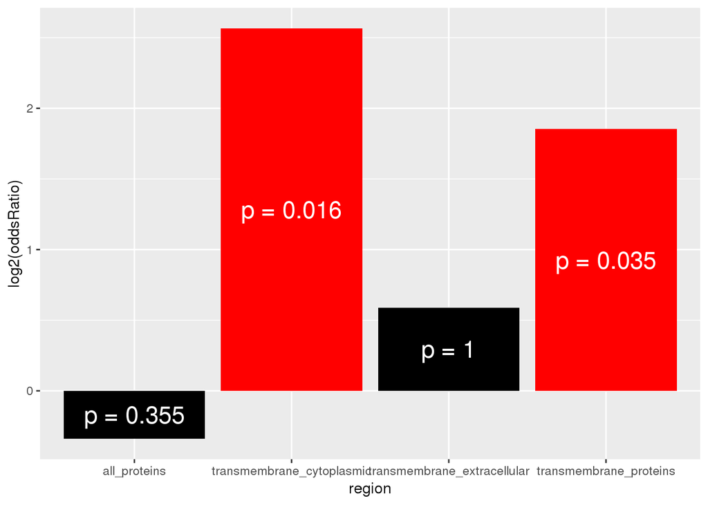

```r
mc <- motifChanges[SLiM == 'LIG_diLeu_1']

l <- list('all_proteins' = compareMotifChangesByVariantType(vars = variants,
                                  motifChanges = mc,
                                  changeType = 'gained'),
     'transmembrane_proteins' = compareMotifChangesByVariantType(
       vars =  variants[variants$uniprotAccession %in% tmProteins,],
                                  motifChanges = mc,
                                  changeType = 'gained'),
     'transmembrane_extracellular' = compareMotifChangesByVariantType(
       vars = variants[getVariantsByRegion(variants, etm),],
                                  motifChanges = mc,
                                  changeType = 'gained'),
     'transmembrane_cytoplasmic' = compareMotifChangesByVariantType(
       vars = variants[getVariantsByRegion(variants, ctm),],
                                  motifChanges = mc,
                                  changeType = 'gained'))
df <- do.call(rbind, lapply(names(l), function(r) {
  df <- l[[r]]
  df$region <- r
  return(df)
}))

ggplot2::ggplot(data = df,
                  aes(x = region, y = log2(oddsRatio))) +
    geom_bar(aes(fill = ifelse(pval < 0.05, 'red', 'black')), position = 'dodge', stat = 'identity') +
  geom_text(aes(label = paste('p =',round(pval, 3)),
                y = log2(oddsRatio)/2),
            color = 'white', size = 6) +
  scale_fill_identity()
```

## 6.2 Reproduce Figure S6C

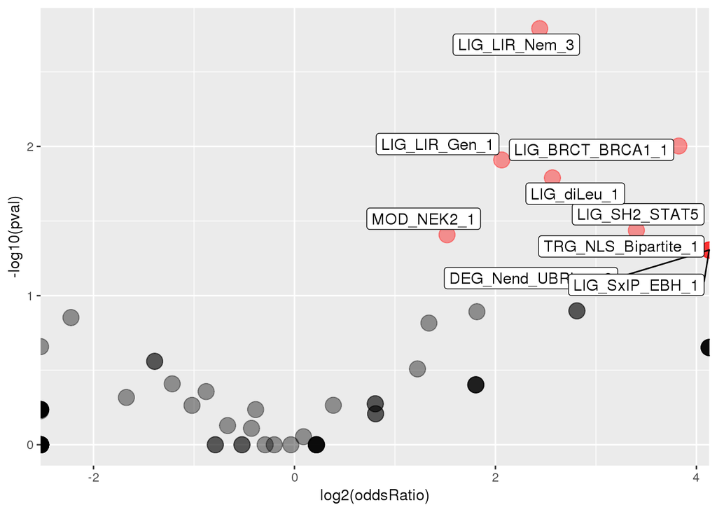

```r
#cytoplasmic regions of transmembrane proteins
vars = variants[getVariantsByRegion(variants, ctm),]
dt <- compareMotifChangesByVariantType(vars = vars, motifChanges = motifChanges, changeType = 'gained')
ggplot(dt, aes(x = log2(oddsRatio), y = -log10(pval))) +
  geom_point(aes(color = ifelse(pval < 0.05, 'red', 'black')), size = 5, alpha = 0.4) +
  geom_label_repel(aes(label = ifelse(pval < 0.05, SLiM, ''))) +
  scale_color_identity()
```